# Seminario de Investigación: Paper

Daniela Verónica Valladares

19/5/2020

```r
survey<-read.csv("encuesta_limpia.csv",sep=",", header=T)
```

## Introducción

En el siguiente análisis haremos un pequeño estudio sobre las características de los estudiantes que estudian actualmente en la universidad y el riesgo que tienen de cambiarse de carrera por diferentes factores. Se quiere saber específicamente cómo podemos prevenir que sucedan este tipo de situaciones. La recolección de datos aquí reflejada se obtuvo mediante aplicación de encuestas a los estudiantes de la facultad de ingeniería de la Universidad Nacional Autónoma de Honduras.

Sabemos el alto impacto que ocasiona al estudiante no sentirse conforme con su elección universitaria y que lo lleva a tomar la decisión de realizar un cambio de carrera, y no solamente afecta en el tiempo y recursos invertidos de estudiante, sino también en los recursos de la Universidad y en los índices de reprobación en las clases por aquellos alumnos que realmente no sienten la afinidad con la carrera seleccionada. Es por esto que este estudio busca prevenir con sus resultados a ambos actores.

## Variables capturadas

```
## 'data.frame':    198 obs. of  50 variables:
##  $ Timestamp                      : chr  "2020/04/07 4:49:53 p.m. GMT-5" "2020/04/07 5:15:30 p.m. GMT-5" "2020/04/08 8:04:40 p.m. GMT-5" "2020/04/09 11:22:32 a.m. GMT-5" ...
##  $ edad                           : chr  "21-24 años" "21-24 años" "21-24 años" "21-24 años" ...
##  $ lugar_residencia               : chr  "Padres" "Padres" "Padres" "Familiares" ...
##  $ lugar_origen                   : chr  "Francisco Morazán" "Choluteca" "Francisco Morazán" "Comayagua" ...
##  $ trabaja                        : chr  "Si" "No" "Si" "No" ...
##  $ ingreso_mensual                : chr  "0 - 3000 L." "Mayor a 6000 L." "Mayor a 6000 L." "0 - 3000 L." ...
##  $ familiares_graduados           : chr  "Si" "Si" "Si" "Si" ...
##  $ familiares_misma_carrera       : chr  "No" "No" "No" "No" ...
##  $ conocimiento_plan_estudios     : chr  "Si" "Si" "No" "Si" ...
##  $ asesoria_universitaria         : chr  "Ninguna" "Ninguna" "Ninguna" "Ninguna" ...
##  $ conocimiento_areas_carrera     : chr  "Si" "Si" "Si" "Si" ...
##  $ previo_test_vocacional         : chr  "Si" "Si" "No" "No" ...
##  $ lugar_test_vocacional          : chr  "Colegio;Internet" "Internet" "" "" ...
##  $ momento_test_vocacional        : chr  "Antes de cursar la carrera" "Durante la carrera" "" "" ...
```

[output cut: 36 more lines]

Como se puede observar se capturaron 198 observaciones y 50 columnas, estas fueron diseñadas en funciones de las siguientes categorias:

1. Información demografica
2. Familiar
3. Orientación
4. Oferta académica
5. Registro
6. Matrícula
7. Hábitos del estudiante
8. Soft Skills

A continuación mostramos un resumen rapido de cada una de nuestra columnas:

```r
summary(survey)
```

```
##   Timestamp             edad           lugar_residencia   lugar_origen
##  Length:198         Length:198         Length:198         Length:198
##  Class :character   Class :character   Class :character   Class :character
##  Mode  :character   Mode  :character   Mode  :character   Mode  :character
##
##
##
##
##    trabaja          ingreso_mensual    familiares_graduados
##  Length:198         Length:198         Length:198
##  Class :character   Class :character   Class :character
##  Mode  :character   Mode  :character   Mode  :character
##
##
##
##
##  familiares_misma_carrera conocimiento_plan_estudios asesoria_universitaria
##  Length:198               Length:198                 Length:198
##  Class :character         Class :character           Class :character
##  Mode  :character         Mode  :character           Mode  :character
##
##
##
##
##  conocimiento_areas_carrera previo_test_vocacional lugar_test_vocacional
##  Length:198                 Length:198             Length:198
##  Class :character           Class :character       Class :character
##  Mode  :character           Mode  :character       Mode  :character
##
##
##
##
##  momento_test_vocacional resultados_congruentes_test conocimiento_test_unah
##  Length:198              Length:198                  Length:198
##  Class :character        Class :character            Class :character
##  Mode  :character        Mode  :character            Mode  :character
##
##
##
##
```

[output cut: 73 more lines]

```
##  Length:198         Length:198         Length:198         Length:198
##  Class :character   Class :character   Class :character   Class :character
##  Mode  :character   Mode  :character   Mode  :character   Mode  :character
##
##
##
##
##  resolucion_puzzles juegos_estrategia  operaciones_matematicas
##  Length:198         Length:198         Length:198
##  Class :character   Class :character   Class :character
##  Mode  :character   Mode  :character   Mode  :character
##
##
##
##
```

## Tratamiento de columnas

En cualquier estudio de variables Uno de los primeros tratamientos que se deben realizar es la deteccion de valores nulos y según la regla de negocio realizar algún tipo de transformación. Mostramos a continuación nuestros valores nulos obtenidos en el desarrollo:

```
##             column.name na.percentage
## 1 veces._cambio_carrera     0.6464646
## 2       año_reprobacion     0.1060606
```

### Tratamiento veces._cambio_carrera

Si analizamos esta variable podremos encontrar la siguiente información

```r
summary(survey$veces._cambio_carrera)
```

```
##    Min. 1st Qu.  Median    Mean 3rd Qu.    Max.    NA's
##   1.000   1.000   1.000   1.043   1.000   2.000     128
```

```r
survey[is.na(survey$veces._cambio_carrera),"veces_cambio_carrera"] <- 0
summary(survey$veces._cambio_carrera)
```

```
##    Min. 1st Qu.  Median    Mean 3rd Qu.    Max.    NA's
##   1.000   1.000   1.000   1.043   1.000   2.000     128
```

### Tratamiento año_reprobación

Continuamos con el análisis de nuestra segunda variable y podremos encontrar la siguiente información

```r
summary(survey$año_reprobacion)
```

```
##    Min. 1st Qu.  Median    Mean 3rd Qu.    Max.    NA's
##   1.000   1.000   1.000   1.542   2.000   4.000      21
```

Y en esta ocasión existen 21 NA’s en esta columna y nuevamente tomamos que los NA’s se pueden interpretar como ceros, y se imputan dichos valores por el valor sugerido.

```r
survey[is.na(survey$año_reprobacion),"año_reprobacion"] <- 0
summary(survey$año_reprobacion)
```

```
##    Min. 1st Qu.  Median    Mean 3rd Qu.    Max.
##   0.000   1.000   1.000   1.379   2.000   4.000
```

## Analisis descriptivo de datos

En esta seccion comenzamos a realizar un par de transformaciones donde podremos apreciar el resumen estadístico de las siguientes dos variables de interés mostrando los boxplots, histogramas y QQPlots para poder visualizar y comprender mejor su comportamiento.

#### Factores cambio carrera

Se estará trabajando con la siguiente variable puesto que dada la combinación de respuestas que se generaron nos da una alta cantidad de categorías bastante grande y diversificada como podremos observar, por lo que es necesario realizar una transformación de los datos

```r
df_perc <- as.data.frame(prop.table(table(survey$factores_cambio_carrera)))
df_perc <- df_perc %>% arrange(-Freq)
df_perc
```

```
##                                                                                                                Var1
## 1
## 2                                                        Falta de puntos para la carrera a la cual aplico en la PAA
## 3                                                                                    Cambio de intereses personales
## 4                                                                                            No era lo que esperaba
## 5                         Cambio de intereses personales;Falta de puntos para la carrera a la cual aplico en la PAA
## 6                                                             Cambio de intereses personales;No era lo que esperaba
## 7                                            Cambio de intereses personales;Factor económico;No era lo que esperaba
## 8                                                                                                  Factor económico
## 9                                       Factor económico;Falta de puntos para la carrera a la cual aplico en la PAA
## 10                       Influencia familiar;Cambio de intereses personales;Factor económico;No era lo que esperaba
## 11                                No era lo que esperaba;Falta de puntos para la carrera a la cual aplico en la PAA
## 12                                                                     No era lo que esperaba;Rendimiento académico
## 13                                                                  Cambio de intereses personales;Factor económico
## 14                     Cambio de intereses personales;Factor económico;No era lo que esperaba;Rendimiento académico
```

[output cut: 33 more lines]

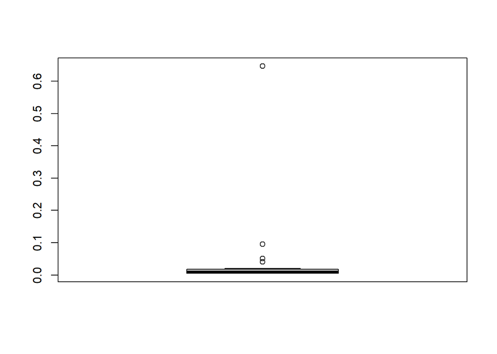

```r
boxplot(df_perc$Freq)
```

Como podemos observar tenemos una alta cantidad de valores atípicos que son muy evidentes en la imagen, es uno de los resultados esperados dada la dispersión de datos.

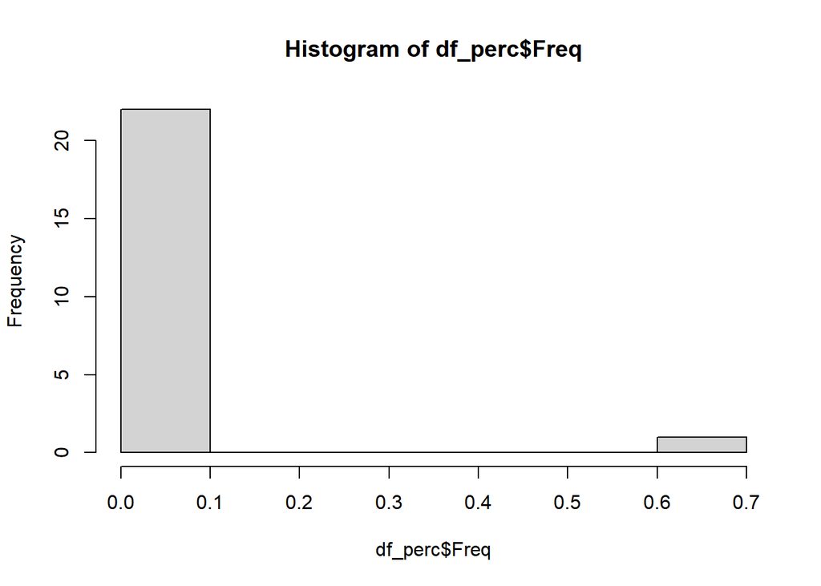

```r
hist(df_perc$Freq)
```

En el histograma podremos apreciar la distancia que existe entre las frecuencias.

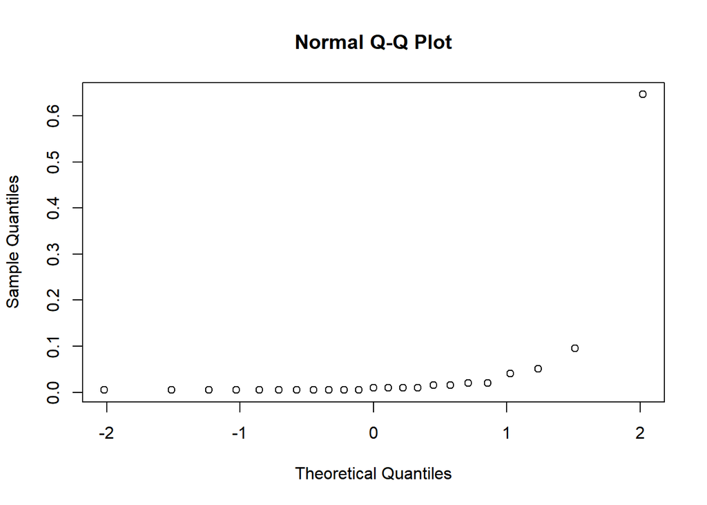

```r
qqnorm(df_perc$Freq)
```

Y en nuestro QQ-Plot podemos obsevar claramente que no existe normalidad.

```r
df_perc[df_perc$Var1 %in% c("Cambio de intereses personales",
                              "Cambio de intereses personales;No era lo que esperaba"),
         "razones_cambio"]<-"Cambio de intereses personales"

df_perc[df_perc$Var1 %in% c("Factor económico",
                              "Factor económico;No era lo que esperaba",
                              "Cambio de intereses personales;Factor económico"),
         "razones_cambio"]<-"Factor económico"

df_perc[df_perc$Var1 %in% c("Falta de puntos para la carrera a la cual aplico en la PAA",
                              "Cambio de intereses personales;Falta de puntos para la carrera
                              a la cual aplico en la PAA",
                              "Cambio de intereses personales;No era lo que esperaba;Falta de
                              puntos para la carrera a la cual aplico en la PAA",
                              "Factor económico;Falta de puntos para la carrera a la cual
                              aplico en la PAA"),
         "razones_cambio"]<-"Falta de puntos en la PAA"


df_perc[df_perc$Var1 %in% c("Influencia familiar",
                              "Influencia familiar;Cambio de intereses personales;Factor
                              económico;No era lo que esperaba",
                              "Influencia familiar;Cambio de intereses personales;No era lo
                              que esperaba",
                              "Influencia familiar;Falta de puntos para la carrera a la cual
                              aplico en la PAA",
                              "Influencia familiar;No era lo que esperaba",
                              "Influencia familiar;No era lo que esperaba;Falta de puntos
                              para la carrera a la cual aplico en la PAA"),
         "razones_cambio"]<-"Influencia familiar"

df_perc[df_perc$Var1 %in% c("No era lo que esperaba",
                              "No era lo que esperaba;Falta de puntos para la carrera a la
                              cual aplico en la PAA",
                              "No era lo que esperaba;Rendimiento académico",
                              "Rendimiento académico",
                              "Cambio de intereses personales;Factor económico;No era lo que
                              esperaba;Rendimiento académico",
                              "Cambio de intereses personales;No era lo que
                              esperaba;Rendimiento académico",
                              "Cambio de intereses personales;Factor económico;No era lo que
                              esperaba"),
         "razones_cambio"]<-"No era lo que esperaba"
df_perc[df_perc$Var1 %in% c("No aplica"),
         "razones_cambio"]<-"No aplica"

df_perc<-df_perc %>% select(Var1,razones_cambio)
survey<-left_join(survey,df_perc,by=c("factores_cambio_carrera"="Var1"))
survey<-survey[,!(names(survey) %in% c("factores_cambio_carrera"))]
```

Una vez realizados los cambios y generando las nuevas categorias podemos apreciar las frecuencias de la siguiente manera:

```r
names(survey)[length(names(survey))]<-"factores_cambio_carrera"
prop.table(table(survey$factores_cambio_carrera))
```

```
##
## Cambio de intereses personales               Factor económico
##                     0.27450980                     0.09803922
##      Falta de puntos en la PAA            Influencia familiar
##                     0.37254902                     0.03921569
##         No era lo que esperaba
##                     0.21568627
```

#### factores multiple carrera

```r
df_perc7 <- as.data.frame(prop.table(table(survey$multiple_carrera)))
df_perc7 <- df_perc7 %>% arrange(-Freq)
df_perc7
```

```
##                              Var1        Freq
## 1                                 0.540404040
## 2                              No 0.343434343
## 3                              no 0.055555556
## 4            Diplomado de Inglés  0.005050505
## 5  Ingeniería de Sonido en línea  0.005050505
## 6                      Matemática 0.005050505
## 7                     Matematicas 0.005050505
## 8                         Ninguna 0.005050505
## 9                              NO 0.005050505
## 10                            No  0.005050505
## 11                            No. 0.005050505
## 12                             Si 0.005050505
## 13                     Sí, Letras 0.005050505
## 14                       Solo una 0.005050505
## 15               Técnico en reded 0.005050505
```

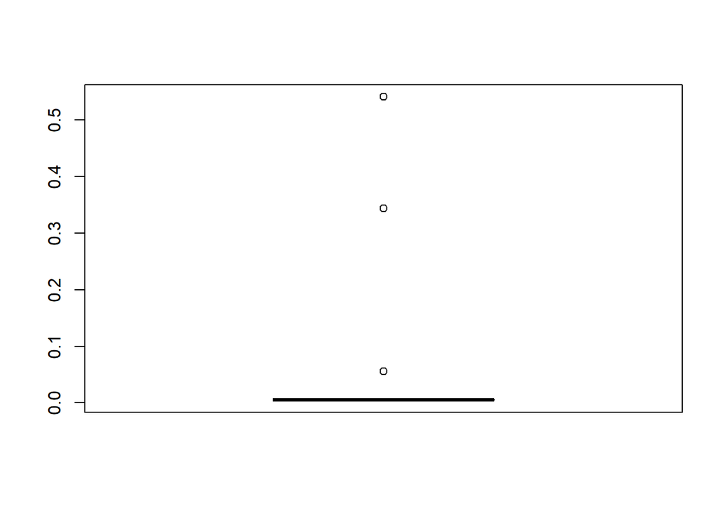

```r
boxplot(df_perc7$Freq)
```

Como podemos observar tenemos una alta cantidad de valores atípicos que son muy evidentes en la imagen, es uno de los resultados esperados dada la dispersión de datos.

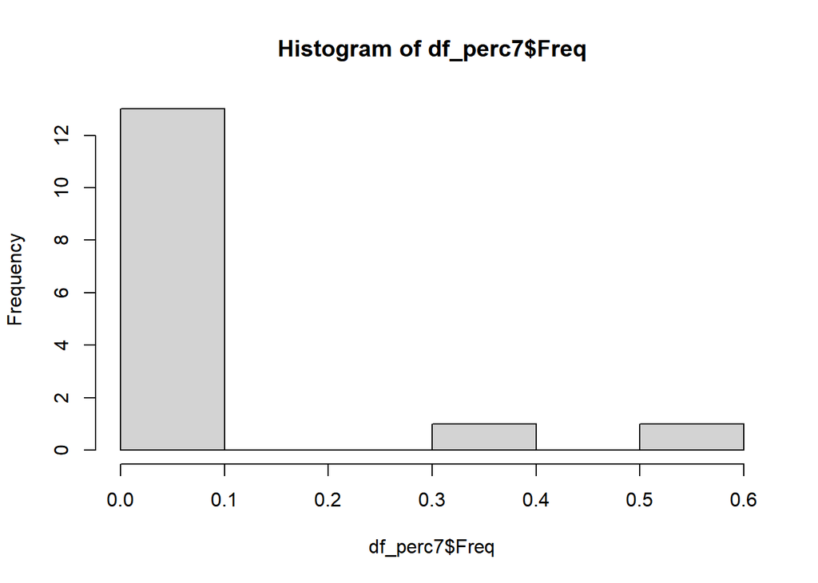

```r
hist(df_perc7$Freq)
```

En el histograma podremos apreciar la distancia que existe entre las frecuencias.

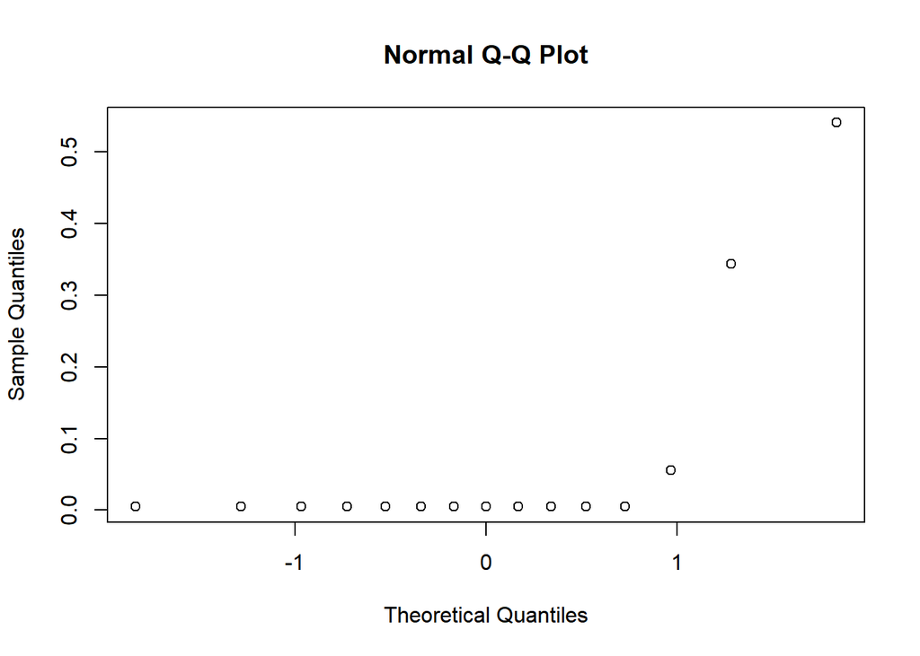

```r
qqnorm(df_perc7$Freq)
```

Y en nuestro QQ-Plot podemos obsevar claramente que no existe normalidad.

```r
df_perc7[df_perc7$Var1 %in% c("Diplomado de Inglés","Técnico en reded","Si","Sí, Letras","Diplomado de Inglés ", "Ingeniería de Sonido en línea ","Matemática","Matematicas"),"multiple_carrera2"]<-"Si"
df_perc7[df_perc7$Var1 %in% c("","No ","Ninguna","no","No   ","No.","NO","No","Solo una"),"multiple_carrera2"]<-"No"


df_perc7<-df_perc7 %>% select(Var1,multiple_carrera2)
survey<-left_join(survey,df_perc7,by=c("multiple_carrera"="Var1"))
survey<-survey[,!(names(survey) %in% c("multiple_carrera"))]
```

Una vez realizados los cambios y generando las nuevas categorias podemos apreciar las frecuencias de la siguiente manera:

```r
names(survey)[length(names(survey))]<-"multiple_carrera"
prop.table(table(survey$factores_cambio_carrera))
```

[output not shown]

## Correlaciones

Comenzaremos esta sección analizando la correlación entre las variables Previo_test_vocacional y conocimiento_test_vocacional

```r
prop.table(table(survey$previo_test_vocacional,survey$conocimiento_test_unah),2)
```

```
##
##             No        Si
##   No 0.6976744 0.5089286
##   Si 0.3023256 0.4910714
```

Esta correlación se realiza para saber que relación existe entre un estudiante que haya realizado un test vocacional antes de comenzar su carrera universitaria y que tenga conocimiento o no de los test que se realizan en UNAH:

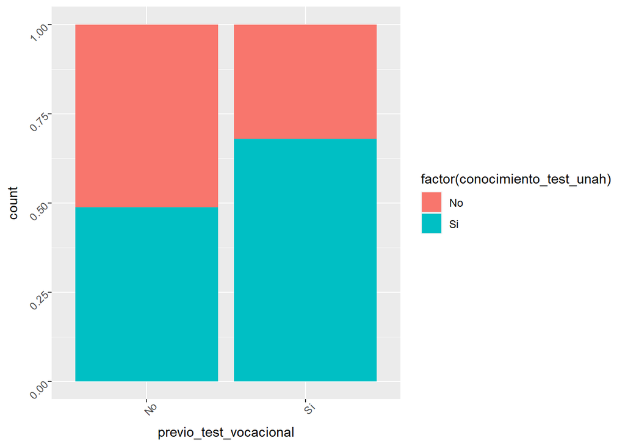

```r
ggplot(survey)+
  aes(x=previo_test_vocacional,fill=factor(conocimiento_test_unah))+
  geom_bar(position = "fill")+
  theme(axis.text = element_text(angle = 45))
```

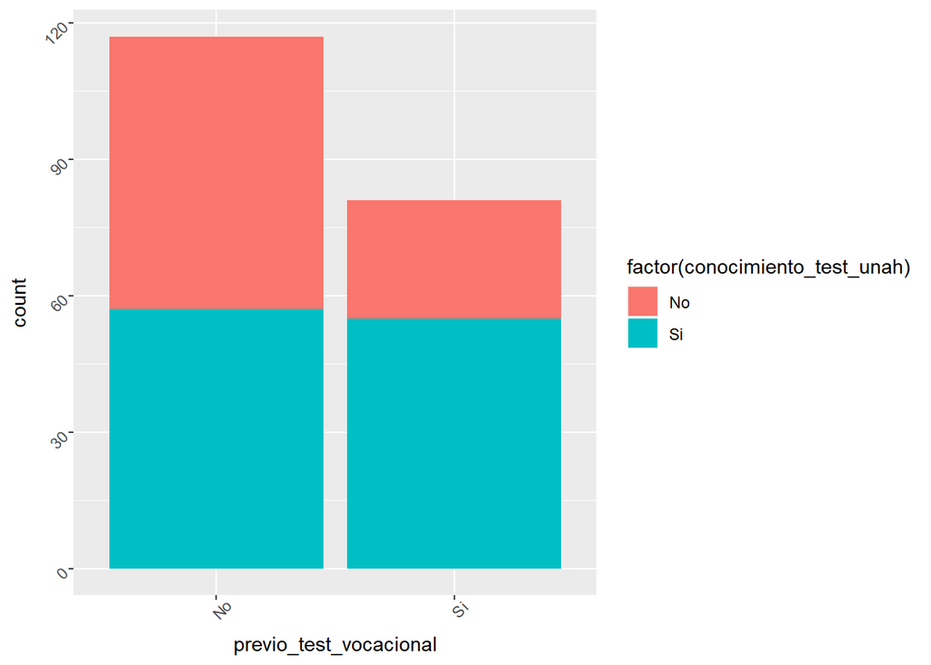

```r
ggplot(survey)+
  aes(x=previo_test_vocacional,fill=factor(conocimiento_test_unah))+
  geom_bar(position = "stack")+
  theme(axis.text = element_text(angle = 45))
```

Para determinar si las dos variables eran independientes o no, se realizó la prueba de chi cuadrado y se formularon dos hipótesis:

H_0: Las categorías de previo test vocacional y conocimiento test unah son independientes.

H_A: Las categorías son dependientes.

```r
chisq.test(table(survey$previo_test_vocacional,survey$conocimiento_test_unah))
```

```
##
##  Pearson's Chi-squared test with Yates' continuity correction
##
## data:  table(survey$previo_test_vocacional, survey$conocimiento_test_unah)
## X-squared = 6.4096, df = 1, p-value = 0.01135
```

Indice_academico y porcentaje_clases_facultad

```r
prop.table(table(survey$previo_test_vocacional,survey$conocimiento_test_unah),2)
```

[output not shown]

Esta correlación se realiza para conocer si al estudiante le causa algún impacto la cantidad de clases que ha aprobado el estudiante a su indice académico y ver si este puede ser un factor de cambio de carrera:

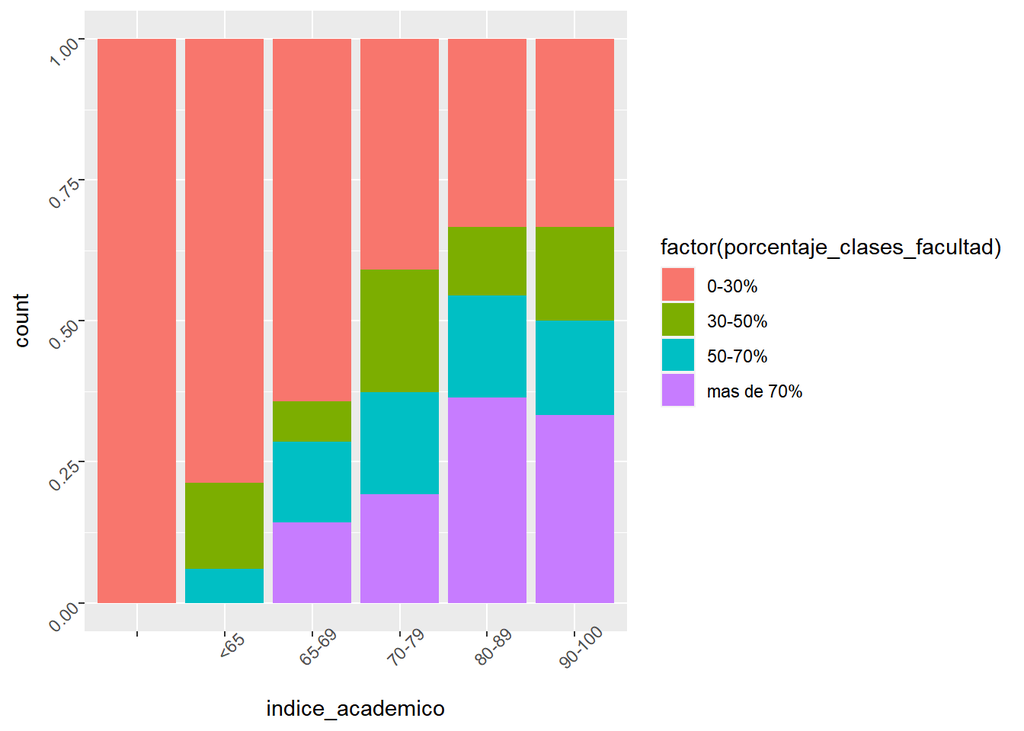

```r
ggplot(survey)+
  aes(x=indice_academico,fill=factor(porcentaje_clases_facultad))+
  geom_bar(position = "fill")+
  theme(axis.text = element_text(angle = 45))
```

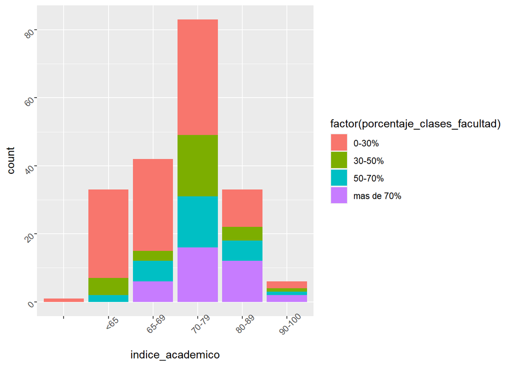

```r
ggplot(survey)+
  aes(x=indice_academico,fill=factor(porcentaje_clases_facultad))+
  geom_bar(position = "stack")+
  theme(axis.text = element_text(angle = 45))
```

Para determinar si las dos variables eran independientes o no, se realizó la prueba de chi cuadrado y se formularon dos hipótesis:

H_0: Las categorías de índice academico y porcentaje clases facultad son independientes.

H_A: Las categorías son dependientes.

```r
chisq.test(table(survey$indice_academico,survey$porcentaje_clases_facultad))
```

```
##
##  Pearson's Chi-squared test
##
## data:  table(survey$indice_academico, survey$porcentaje_clases_facultad)
## X-squared = 31.24, df = 15, p-value = 0.008159
```

Factores_no_cambio vs porcentaje_Clases_Cursadas

```r
prop.table(table(survey$factores_no_cambio,survey$procentaje_clases_cursadas),2)
```

```
##
##                                                                                                                                                                 0-20%
##                                                                                                                                                            0.60344828
##   El sistema de cambio de carrera no te lo permite                                                                                                         0.01724138
##   El sistema de cambio de carrera no te lo permite;No cuentas con todos los requisitos para el proceso.                                                    0.01724138
##   Estás realizando o vas a relizar un cambio de carrera                                                                                                    0.03448276
##   Estás realizando o vas a relizar un cambio de carrera;No cuentas con todos los requisitos para el proceso.                                               0.01724138
##   No cuentas con todos los requisitos para el proceso.                                                                                                     0.03448276
##   Opinion familiar/amigos                                                                                                                                  0.05172414
##   Opinion familiar/amigos;El sistema de cambio de carrera no te lo permite;No cuentas con todos los requisitos para el proceso.                            0.01724138
##   Opinion familiar/amigos;Factor economico                                                                                                                 0.01724138
##   Opinion familiar/amigos;No cuentas con todos los requisitos para el proceso.                                                                             0.00000000
##   Recursos y tiempo invertidos en la carrera                                                                                                               0.08620690
##   Recursos y tiempo invertidos en la carrera;El sistema de cambio de carrera no te lo permite;No cuentas con todos los requisitos para el proceso.         0.00000000
##   Recursos y tiempo invertidos en la carrera;Factor economico                                                                                              0.01724138
##   Recursos y tiempo invertidos en la carrera;Factor economico;No cuentas con todos los requisitos para el proceso.                                         0.01724138
##   Recursos y tiempo invertidos en la carrera;Opinion familiar/amigos                                                                                       0.03448276
##   Recursos y tiempo invertidos en la carrera;Opinion familiar/amigos;Estás realizando o vas a relizar un cambio de carrera                                 0.00000000
##   Recursos y tiempo invertidos en la carrera;Opinion familiar/amigos;Factor economico                                                                      0.00000000
##   Recursos y tiempo invertidos en la carrera;Opinion familiar/amigos;Factor economico;El sistema de cambio de carrera no te lo permite                     0.01724138
##   Recursos y tiempo invertidos en la carrera;Opinion familiar/amigos;No cuentas con todos los requisitos para el proceso.                                  0.00000000
##   Tu edad                                                                                                                                                  0.01724138
##   Tu edad;El sistema de cambio de carrera no te lo permite;No cuentas con todos los requisitos para el proceso.                                            0.00000000
##   Tu edad;Recursos y tiempo invertidos en la carrera                                                                                                       0.00000000
##   Tu edad;Recursos y tiempo invertidos en la carrera;El sistema de cambio de carrera no te lo permite;No cuentas con todos los requisitos para el proceso. 0.00000000
##   Tu edad;Recursos y tiempo invertidos en la carrera;Estás realizando o vas a relizar un cambio de carrera                                                 0.00000000
```

[output cut: 64 more lines]

Se desea conocer si es un factor influyente en tomar la decisión de hacer un cambio de carrera el porcentaje de clases aprobadas por el estudiante:

[figure not shown]

```r
ggplot(survey)+
  aes(x=factores_no_cambio,fill=factor(procentaje_clases_cursadas))+
  geom_bar(position = "fill")+
  theme(axis.text.x = element_text(angle = 0))
```

[figure not shown]

```r
ggplot(survey)+
  aes(x=factores_no_cambio,fill=factor(procentaje_clases_cursadas))+
  geom_bar(position = "stack")+
  theme(axis.text.x = element_text(angle = 0))
```

Para determinar si las dos variables eran independientes o no, se realizó la prueba de chi cuadrado y se formularon dos hipótesis:

H_0: Las categorías de factores no cambio y porcentaje clases cursadas son independientes.

H_A: Las categorías son dependientes.

```r
chisq.test(table(survey$indice_academico,survey$porcentaje_clases_facultad))
```

[output not shown]

## Explicativa

```r
survey<-read.csv("encuesta_transformada_regresion.csv",sep=",", header=T)
```

```r
survey$cambio_carrera <- as.character(survey$cambio_carrera)

survey[survey$cambio_carrera %in% 'No', 'cambio_carrera'] <- "0"
survey[survey$cambio_carrera %in% 'Sí', 'cambio_carrera'] <- "1"

survey$cambio_carrera <- as.factor(survey$cambio_carrera)
```

Variables tomadas en cuenta para realizar la regresión

```r
set <- survey[,(names(survey) %in% c(
  'lugar_residencia',
  'horas_estudio_diario',
  'porcentaje_clases_matematica',
  'satisfaccion_carrera',
  'estudia_grupo',
  'motivacion',
  'trabaja',
  'edad',
  'asesoria_universitaria',
  'pensado_cambio_carrera'
)
)]
```

```r
cambio_carrera <- survey[,'cambio_carrera']
```

```r
model <- glm(cambio_carrera ~ ., data = set, family = "binomial")
```

Continuamos con la gráficas

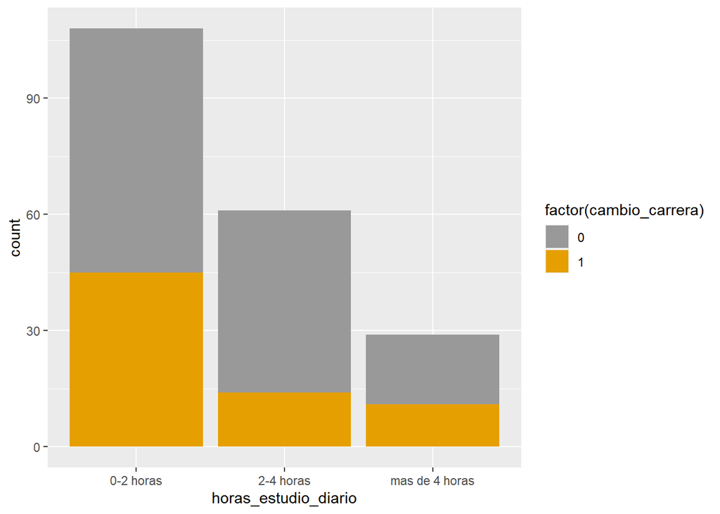

```r
ggplot(set) +
  aes(x = horas_estudio_diario, fill = factor(cambio_carrera)) +
  geom_bar(position = "stack") +
  theme(axis.text.x = element_text(angle = 0)) +
  scale_fill_manual(values=c("#999999","#E69F00"))
```

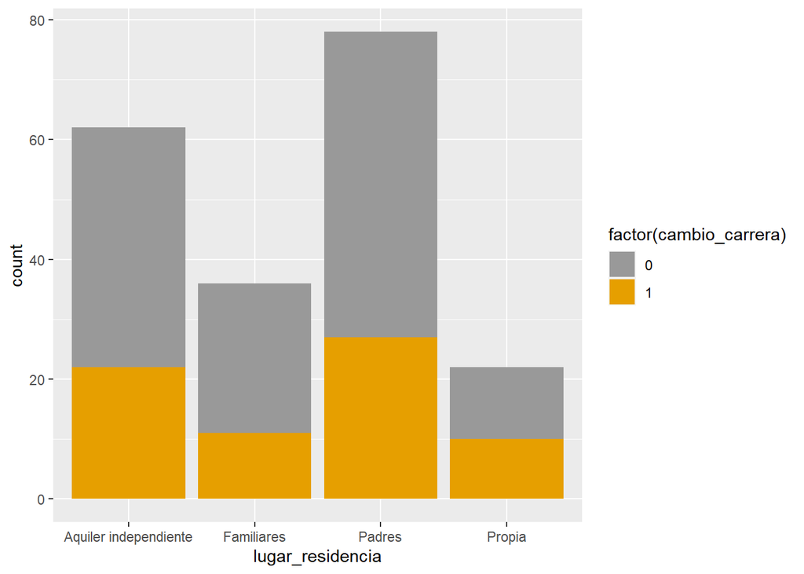

```r
ggplot(set) +
  aes(x = lugar_residencia, fill = factor(cambio_carrera)) +
  geom_bar(position = "stack") +
  theme(axis.text.x = element_text(angle = 0)) +
  scale_fill_manual(values=c("#999999","#E69F00"))
```

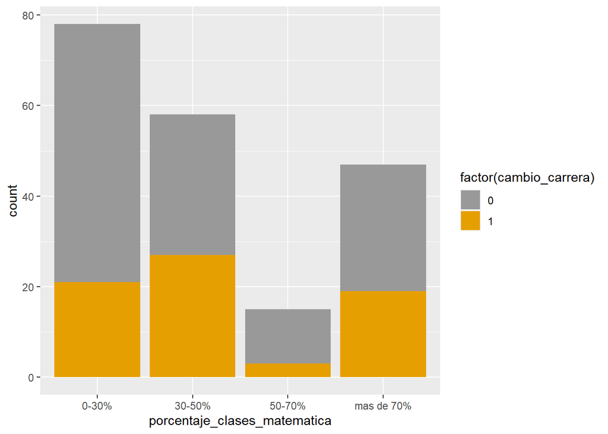

```r
ggplot(set) +
  aes(x = porcentaje_clases_matematica, fill = factor(cambio_carrera)) +
  geom_bar(position = "stack") +
  theme(axis.text.x = element_text(angle = 0)) +
  scale_fill_manual(values=c("#999999","#E69F00"))
```

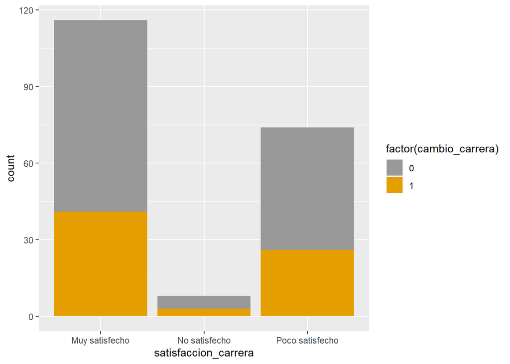

```r
ggplot(set) +
  aes(x = satisfaccion_carrera, fill = factor(cambio_carrera)) +
  geom_bar(position = "stack") +
  theme(axis.text.x = element_text(angle = 0)) +
  scale_fill_manual(values=c("#999999","#E69F00"))
```

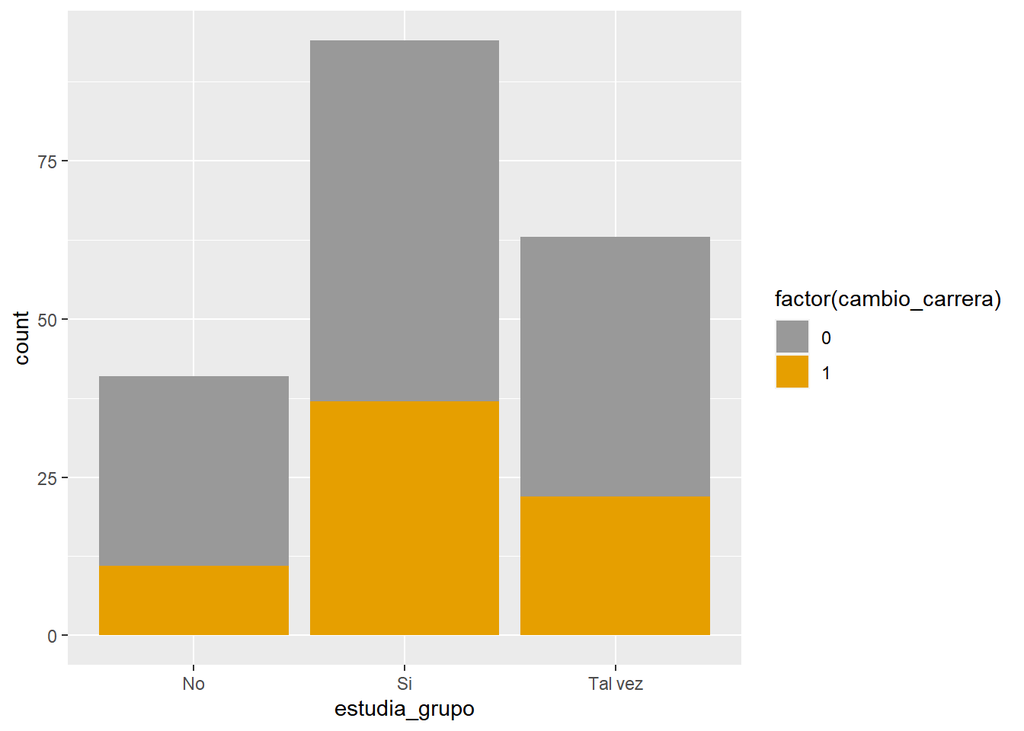

```r
ggplot(set) +
  aes(x = estudia_grupo, fill = factor(cambio_carrera)) +
  geom_bar(position = "stack") +
  theme(axis.text.x = element_text(angle = 0)) +
  scale_fill_manual(values=c("#999999","#E69F00"))
```

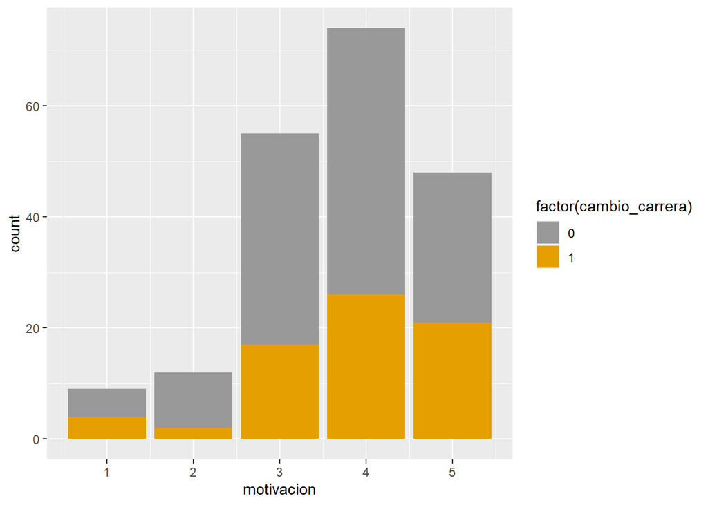

```r
ggplot(set) +
  aes(x = motivacion, fill = factor(cambio_carrera)) +
  geom_bar(position = "stack") +
  theme(axis.text.x = element_text(angle = 0)) +
  scale_fill_manual(values=c("#999999","#E69F00"))
```

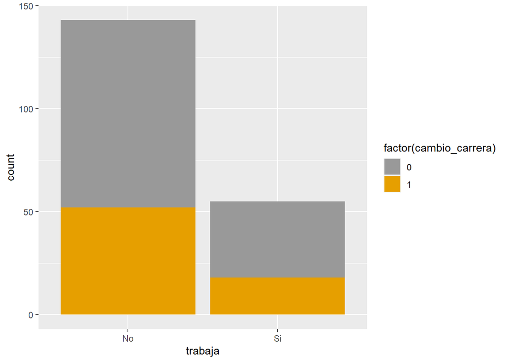

```r
ggplot(set) +
  aes(x = trabaja, fill = factor(cambio_carrera)) +
  geom_bar(position = "stack") +
  theme(axis.text.x = element_text(angle = 0)) +
  scale_fill_manual(values=c("#999999","#E69F00"))
```

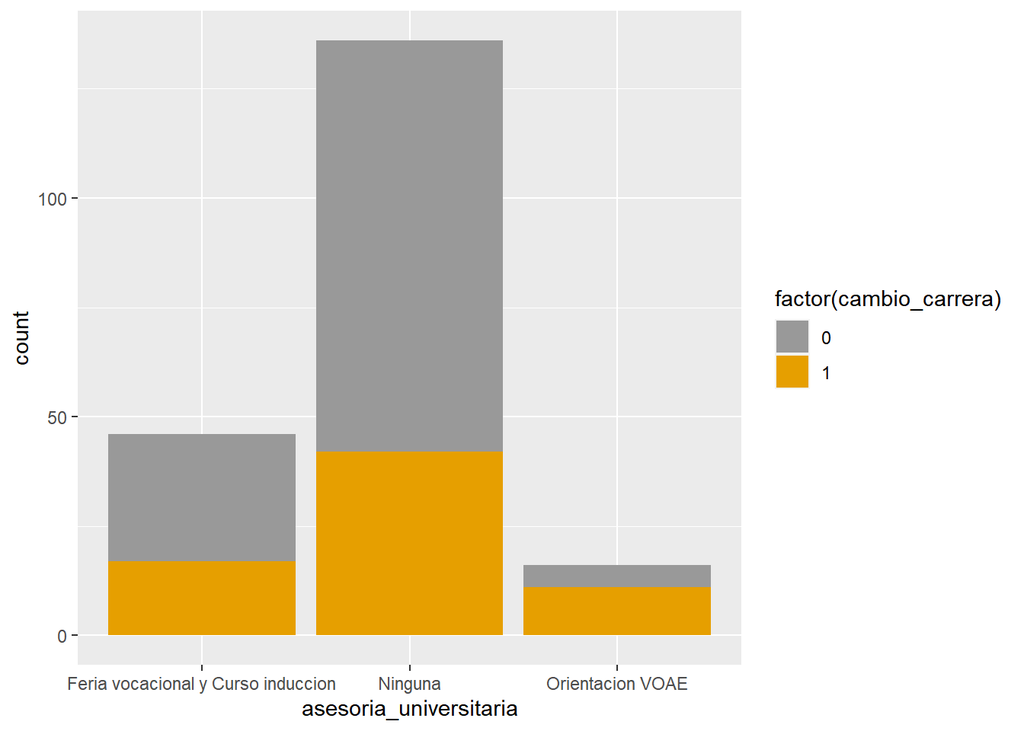

```r
ggplot(set) +
  aes(x = asesoria_universitaria, fill = factor(cambio_carrera)) +
  geom_bar(position = "stack") +
  theme(axis.text.x = element_text(angle = 0)) +
  scale_fill_manual(values=c("#999999","#E69F00"))
```

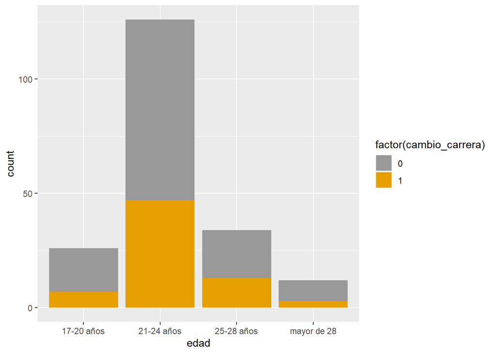

```r
ggplot(set) +
  aes(x = edad, fill = factor(cambio_carrera)) +
  geom_bar(position = "stack") +
  theme(axis.text.x = element_text(angle = 0)) +
  scale_fill_manual(values=c("#999999","#E69F00"))
```

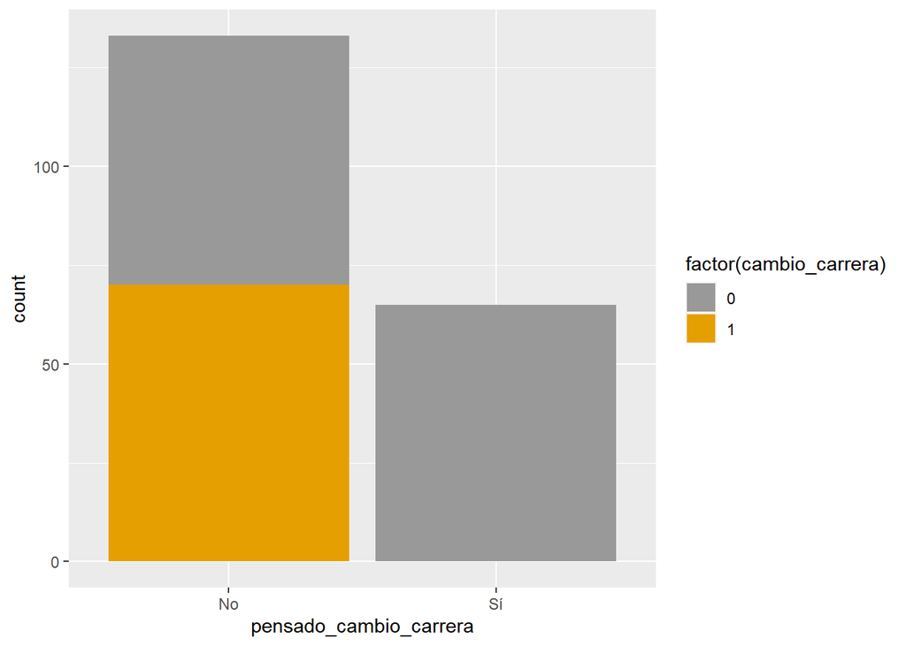

```r
ggplot(set) +
  aes(x = pensado_cambio_carrera, fill = factor(cambio_carrera)) +
  geom_bar(position = "stack") +
  theme(axis.text.x = element_text(angle = 0)) +
  scale_fill_manual(values=c("#999999","#E69F00"))
```

```r
fpath <- 'solucion.png'
im <- load.image(fpath)
```